# ASSIGNMENT 6 (MACHINE LEARNING)

# Q1: PLOT 10 FIGURES OF CHOICE

# NOTE: I PLOTTED 12 FIGURES. AT FIRST I ANALYZED THE DATA AND TRIED TO MAP SEVERAL OUTCOMES, RELATIONS, AND INDIVIDUAL COLUMN ANALYSIS

```python
import pandas as pd
import matplotlib.pyplot as plt
import numpy as np
import seaborn as sns
```

```python
dt = pd.read_csv('LandslidesGlobal(1).csv')
```

```python
dt
```

|  | id | date | time | country | nearest_places | hazard_type | landslide_type | trigger | storm_name | fatalities | ... | population | countrycode | continentcode | key | version | tstamp | changeset_id | latitude | longitude | geolocation |
| --- | --- | --- | --- | --- | --- | --- | --- | --- | --- | --- | --- | --- | --- | --- | --- | --- | --- | --- | --- | --- | --- |
| 0 | 1 | 01/02/2007 | NaN | United Kingdom | Whitehaven, Cumbria | landslide | Landslide | Rain | NaN | 1.0 | ... | 24803.0 | GB | EU | sGaiIKdcW | 1.0 | Tue Apr 01 2014 00:00:00 GMT+0000 (UTC) | 1.0 | 54.549400 | -3.587500 | (54.549399999999999, -3.5874999999999999) |
| 1 | 2 | 01/03/2007 | NaN | Peru | Alto Mesapata, in the Pasco province | landslide | Complex | Rain | NaN | NaN | ... | 0.0 | PE | SA | S95OsumK4 | 1.0 | Tue Apr 01 2014 00:00:00 GMT+0000 (UTC) | 1.0 | -10.383800 | -75.426700 | (-10.383800000000001, -75.426699999999997) |
| 2 | 3 | 01/05/2007 | NaN | Brazil | Nova Friburgo, Rio de Janeiro | landslide | Landslide | Rain | NaN | 7.0 | ... | 153361.0 | BR | SA | D5vlNdgB7 | 1.0 | Tue Apr 01 2014 00:00:00 GMT+0000 (UTC) | 1.0 | -22.282346 | -42.536362 | (-22.282346350000001, -42.536362050000001) |
| 3 | 4 | 01/05/2007 | NaN | Brazil | Sumidouro, Rio de Janeiro | landslide | Landslide | Rain | NaN | 2.0 | ... | 11555.0 | BR | SA | h5J8IFdc4 | 1.0 | Tue Apr 01 2014 00:00:00 GMT+0000 (UTC) | 1.0 | -22.045200 | -42.673400 | (-22.045200000000001, -42.673400000000001) |
| 4 | 5 | 01/05/2007 | NaN | Brazil | Jundiai, Sao Paulo | landslide | Landslide | Rain | NaN | 1.0 | ... | 54415.0 | BR | SA | s5Zb5FdB4 | 1.0 | Tue Apr 01 2014 00:00:00 GMT+0000 (UTC) | 1.0 | -23.231100 | -46.613600 | (-23.231100000000001, -46.613599999999998) |
| ... | ... | ... | ... | ... | ... | ... | ... | ... | ... | ... | ... | ... | ... | ... | ... | ... | ... | ... | ... | ... | ... |
| 9559 | 765 | 08/30/2008 | NaN | Nepal | Barbhanjyang VDC-8, Tanahun District | landslide | Landslide | Downpour | NaN | 2.0 | ... | 107157.0 | NP | AS | sJVPilQc7 | 1.0 | Tue Apr 01 2014 00:00:00 GMT+0000 (UTC) | 1.0 | 28.010319 | 84.377406 | (28.010318739999999, 84.377406140000005) |
| 9560 | 9682 | 08/30/2008 | NaN | Nepal | Chokchissapani VDC-9, Tanahun District | landslide | Landslide | Downpour | NaN | 3.0 | ... | 107157.0 | NP | AS | sJVPilQc7 | 1.0 | Tue Apr 01 2014 00:00:00 GMT+0000 (UTC) | 1.0 | 28.100258 | 84.421435 | (28.100258220000001, 84.421435259999996) |
| 9561 | 9683 | 07/03/2011 | NaN | Nepal | Diktel-Bhojpur road in Khotang | landslide | Landslide | Continuous_rain | NaN | 0.0 | ... | 3250.0 | NP | AS | sGq1pkQBW | 1.0 | Tue Apr 01 2014 00:00:00 GMT+0000 (UTC) | 1.0 | 27.218190 | 86.919138 | (27.218190150000002, 86.919138230000001) |
| 9562 | 9684 | 07/03/2011 | NaN | Nepal | Jayaram-Diktel road in Khotang | landslide | Landslide | Continuous_rain | NaN | NaN | ... | 3250.0 | NP | AS | sGq1pkQBW | 1.0 | Tue Apr 01 2014 00:00:00 GMT+0000 (UTC) | 1.0 | 27.205173 | 86.656833 | (27.205173460000001, 86.656833419999998) |
| 9563 | 9685 | 07/03/2011 | NaN | Nepal | Hurlung Jalapa in Khotang | landslide | Landslide | Continuous_rain | NaN | NaN | ... | 3250.0 | NP | AS | sGq1pkQBW | 1.0 | Tue Apr 01 2014 00:00:00 GMT+0000 (UTC) | 1.0 | 27.306692 | 86.774975 | (27.30669194, 86.774975130000001) |

9564 rows × 34 columns

```python
dt.info()
```

```
<class 'pandas.core.frame.DataFrame'>
RangeIndex: 9564 entries, 0 to 9563
Data columns (total 34 columns):
 #   Column                Non-Null Count  Dtype
---  ------                --------------  -----
 0   id                    9564 non-null   int64
 1   date                  9563 non-null   object
 2   time                  4024 non-null   object
 3   country               6167 non-null   object
 4   nearest_places        9472 non-null   object
 5   hazard_type           9555 non-null   object
 6   landslide_type        9546 non-null   object
 7   trigger               8808 non-null   object
 8   storm_name            550 non-null    object
 9   fatalities            8212 non-null   float64
```

[output cut: 26 more lines]

```python
# Removing unnecessary data

dt1 = dt.drop(["country","photos_link", "adminname1", "adminname2", "tstamp",
         "source_name", "source_link", "nearest_places", "key",
         "version", "changeset_id", "cat_src", "cat_id", "location_description",
        "countrycode", "storm_name", "geolocation"], axis = 1)
dt1
```

|  | id | date | time | hazard_type | landslide_type | trigger | fatalities | injuries | location_accuracy | landslide_size | countryname | near | distance | population | continentcode | latitude | longitude |
| --- | --- | --- | --- | --- | --- | --- | --- | --- | --- | --- | --- | --- | --- | --- | --- | --- | --- |
| 0 | 1 | 01/02/2007 | NaN | landslide | Landslide | Rain | 1.0 | NaN | Known_within_5_km | Medium | United Kingdom | Whitehaven | 0.22405 | 24803.0 | EU | 54.549400 | -3.587500 |
| 1 | 2 | 01/03/2007 | NaN | landslide | Complex | Rain | NaN | NaN | Unknown | Medium | Peru | Huancabamba | 12.26171 | 0.0 | SA | -10.383800 | -75.426700 |
| 2 | 3 | 01/05/2007 | NaN | landslide | Landslide | Rain | 7.0 | NaN | Known_within_25_km | Large | Brazil | Nova Friburgo | 0.63016 | 153361.0 | SA | -22.282346 | -42.536362 |
| 3 | 4 | 01/05/2007 | NaN | landslide | Landslide | Rain | 2.0 | NaN | Known_within_10_km | Medium | Brazil | Carmo | 14.05144 | 11555.0 | SA | -22.045200 | -42.673400 |
| 4 | 5 | 01/05/2007 | NaN | landslide | Landslide | Rain | 1.0 | NaN | Known_within_50_km | Medium | Brazil | Mairipor√£ | 10.07582 | 54415.0 | SA | -23.231100 | -46.613600 |
| ... | ... | ... | ... | ... | ... | ... | ... | ... | ... | ... | ... | ... | ... | ... | ... | ... | ... |
| 9559 | 765 | 08/30/2008 | NaN | landslide | Landslide | Downpour | 2.0 | NaN | Known_within_10_km | Medium | Nepal | Bharatpur | 31.54629 | 107157.0 | AS | 28.010319 | 84.377406 |
| 9560 | 9682 | 08/30/2008 | NaN | landslide | Landslide | Downpour | 3.0 | NaN | Known_within_5_km | Medium | Nepal | Bharatpur | 31.54629 | 107157.0 | AS | 28.100258 | 84.421435 |
| 9561 | 9683 | 07/03/2011 | NaN | landslide | Landslide | Continuous_rain | 0.0 | NaN | Known_within_15_km | Medium | Nepal | Bhojpur | 23.18065 | 3250.0 | AS | 27.218190 | 86.919138 |
| 9562 | 9684 | 07/03/2011 | NaN | landslide | Landslide | Continuous_rain | NaN | NaN | Known_within_25_km | Medium | Nepal | Bhojpur | 23.18065 | 3250.0 | AS | 27.205173 | 86.656833 |
| 9563 | 9685 | 07/03/2011 | NaN | landslide | Landslide | Continuous_rain | NaN | NaN | Known_within_50_km | Medium | Nepal | Bhojpur | 23.18065 | 3250.0 | AS | 27.306692 | 86.774975 |

9564 rows × 17 columns

```python
dt1['year']=pd.DatetimeIndex(dt1['date']).year
dt1
```

|  | id | date | time | hazard_type | landslide_type | trigger | fatalities | injuries | location_accuracy | landslide_size | countryname | near | distance | population | continentcode | latitude | longitude | year |
| --- | --- | --- | --- | --- | --- | --- | --- | --- | --- | --- | --- | --- | --- | --- | --- | --- | --- | --- |
| 0 | 1 | 01/02/2007 | NaN | landslide | Landslide | Rain | 1.0 | NaN | Known_within_5_km | Medium | United Kingdom | Whitehaven | 0.22405 | 24803.0 | EU | 54.549400 | -3.587500 | 2007.0 |
| 1 | 2 | 01/03/2007 | NaN | landslide | Complex | Rain | NaN | NaN | Unknown | Medium | Peru | Huancabamba | 12.26171 | 0.0 | SA | -10.383800 | -75.426700 | 2007.0 |
| 2 | 3 | 01/05/2007 | NaN | landslide | Landslide | Rain | 7.0 | NaN | Known_within_25_km | Large | Brazil | Nova Friburgo | 0.63016 | 153361.0 | SA | -22.282346 | -42.536362 | 2007.0 |
| 3 | 4 | 01/05/2007 | NaN | landslide | Landslide | Rain | 2.0 | NaN | Known_within_10_km | Medium | Brazil | Carmo | 14.05144 | 11555.0 | SA | -22.045200 | -42.673400 | 2007.0 |
| 4 | 5 | 01/05/2007 | NaN | landslide | Landslide | Rain | 1.0 | NaN | Known_within_50_km | Medium | Brazil | Mairipor√£ | 10.07582 | 54415.0 | SA | -23.231100 | -46.613600 | 2007.0 |
| ... | ... | ... | ... | ... | ... | ... | ... | ... | ... | ... | ... | ... | ... | ... | ... | ... | ... | ... |
| 9559 | 765 | 08/30/2008 | NaN | landslide | Landslide | Downpour | 2.0 | NaN | Known_within_10_km | Medium | Nepal | Bharatpur | 31.54629 | 107157.0 | AS | 28.010319 | 84.377406 | 2008.0 |
| 9560 | 9682 | 08/30/2008 | NaN | landslide | Landslide | Downpour | 3.0 | NaN | Known_within_5_km | Medium | Nepal | Bharatpur | 31.54629 | 107157.0 | AS | 28.100258 | 84.421435 | 2008.0 |
| 9561 | 9683 | 07/03/2011 | NaN | landslide | Landslide | Continuous_rain | 0.0 | NaN | Known_within_15_km | Medium | Nepal | Bhojpur | 23.18065 | 3250.0 | AS | 27.218190 | 86.919138 | 2011.0 |
| 9562 | 9684 | 07/03/2011 | NaN | landslide | Landslide | Continuous_rain | NaN | NaN | Known_within_25_km | Medium | Nepal | Bhojpur | 23.18065 | 3250.0 | AS | 27.205173 | 86.656833 | 2011.0 |
| 9563 | 9685 | 07/03/2011 | NaN | landslide | Landslide | Continuous_rain | NaN | NaN | Known_within_50_km | Medium | Nepal | Bhojpur | 23.18065 | 3250.0 | AS | 27.306692 | 86.774975 | 2011.0 |

9564 rows × 18 columns

FIGURE 1: THIS IS ABOUT LANDSLIDE SIZE COUNT TO FURTHER DWELL IN THE DATASET. WHOLE DATA IS RELATED TO EFFECTS CAUSED BY LANDSLIDES AND HAZARDS. SO FOR A GEENRAL IDEA, I PLOTTED THIS IN FIRST PLACE. IT TELLS ME THAT MEDIUM TYPE OF LANSLIDE SIZE OCCURED THE MOST.

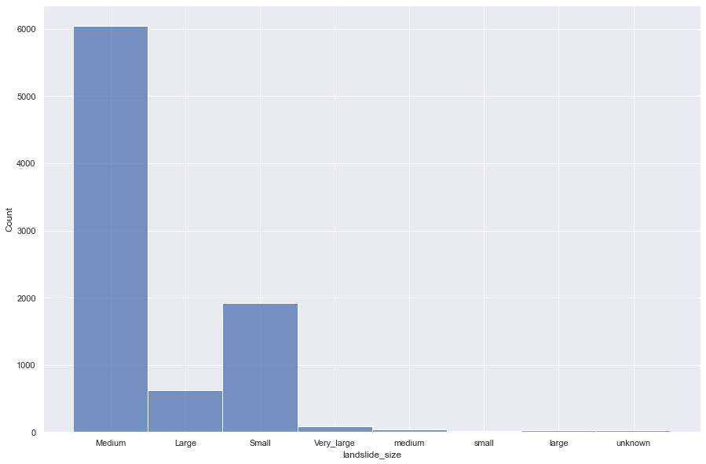

```python
import seaborn as sns
sns.set(style="darkgrid")
plt.subplots(figsize=(15,10))
sns.histplot(data=dt1, x="landslide_size")

plt.show()
```

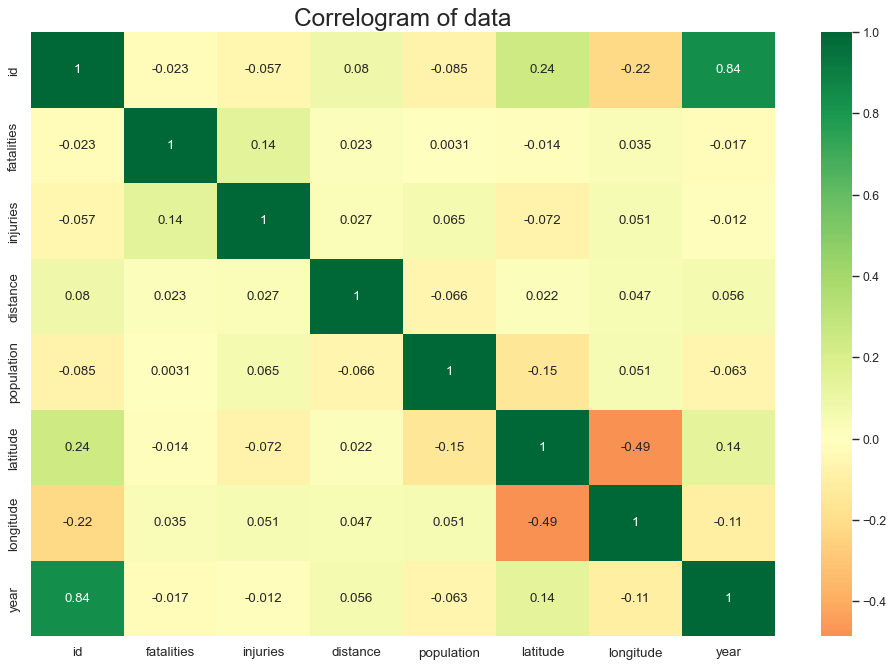

```python
plt.figure(figsize=(15,10), dpi= 80)
sns.heatmap(dt1.corr(), xticklabels=dt1.corr().columns, yticklabels=dt1.corr().columns, cmap='RdYlGn', center=0, annot=True)

# Decorations
plt.title('Correlogram of data', fontsize=22)
plt.xticks(fontsize=12)
plt.yticks(fontsize=12)
plt.show()
```

```python
# Import label encoder
from sklearn import preprocessing

# label_encoder object knows how to understand word labels
label_encoder = preprocessing.LabelEncoder()

dt1['country_name']= label_encoder.fit_transform(dt1['countryname'])
dt1['landslide_size1']= label_encoder.fit_transform(dt1['landslide_size'])
dt1['trigger_label']= label_encoder.fit_transform(dt1['trigger'])
dt1['hazard_type_label']= label_encoder.fit_transform(dt1['hazard_type'])
```

FIGURE 3: IT IS VERY INTERESTING PLOT BETWEEN THE DISTRIBUTION OF DIFFERENT LANDSLIDE SIZES BASED ON THEIR LATITUDES AND LONGITUDES AND WITH RESPECT TO THE YEAR IN WHICH THEY OCCUR.

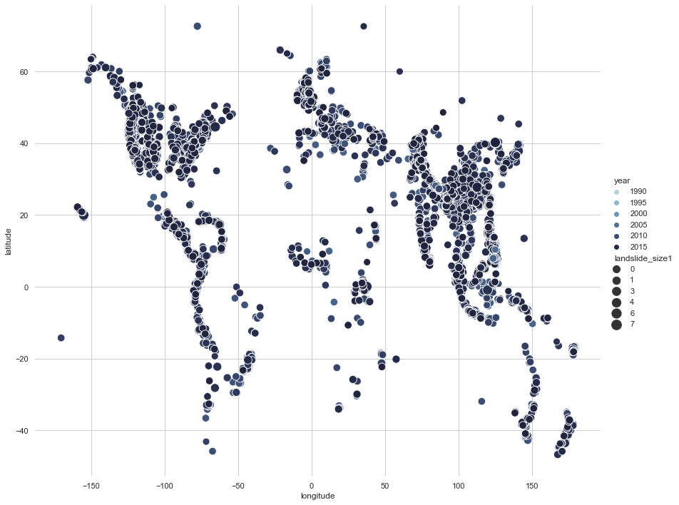

```python
import seaborn as sns
sns.set_theme(style="whitegrid")


cmap = sns.cubehelix_palette(rot=-.2, as_cmap=True)
g = sns.relplot(
    data=dt1,
    x="longitude", y="latitude",
    hue="year", size="landslide_size1",
    palette=cmap, sizes=(100, 200), height = 10, aspect = 1.2,
)
g.set(xscale="linear", yscale="linear")
g.ax.xaxis.grid(True, "minor", linewidth=1.25)
g.ax.yaxis.grid(True, "minor", linewidth=1.25)
g.despine(left=True, bottom=True)
```

FIGURE 4: SCATTER PLOT THAT TELLS US THE RELATIONSHIP BETWEEN POPULATION AND DISTANCE. WE CAN CLEARLY SEE THAT AS THE DISTANCE INCREASES, POPULATION DECREASES.

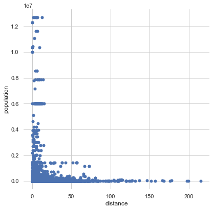

```python
import seaborn as sns
import matplotlib.pyplot as plt
sns.set_theme(style="whitegrid")


# Draw a scatter plot while assigning point colors and sizes to different
# variables in the dataset
f, ax = plt.subplots(figsize=(6.5, 6.5))
sns.despine(f, left=True, bottom=True)
sns.scatterplot(x="distance", y="population",
                palette="ch:r=-.2,d=.3_r",
                sizes=(1, 8), linewidth=0,
                data=dt1, ax=ax)
```

```python
pip install gapminder
```

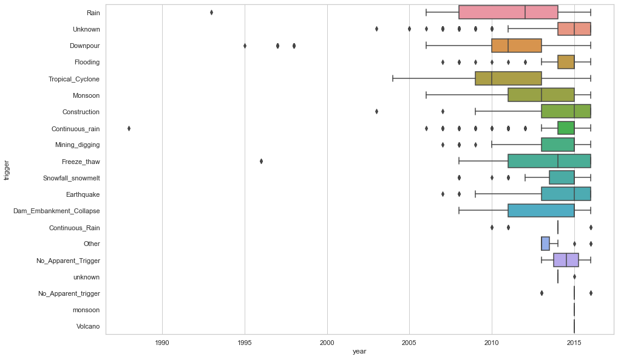

```python
# import library & dataset
import seaborn as sns

plt.subplots(figsize=(15,10))

# Just switch x and y
sns.boxplot(y=dt1["trigger"], x=dt1["year"])
figsize=(100,100)
```

FIGURE 6: IT IS A 3D PLOT. TELLING US POPULATION WITH RESPECT TO LATITUDE AND LONGITUDE.

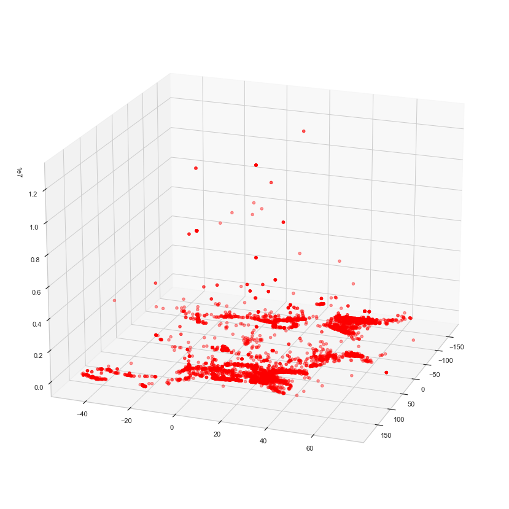

```python
from mpl_toolkits import mplot3d


fig = plt.figure(figsize=(15,15))

ax = plt.axes(projection='3d')
ax.scatter3D(dt1["longitude"], dt1["latitude"], dt1["population"], alpha=.4, color = 'red')

#for changing the view
ax.view_init(20,20)
```

```python
dt1
```

|  | id | date | time | hazard_type | landslide_type | trigger | fatalities | injuries | location_accuracy | landslide_size | ... | distance | population | continentcode | latitude | longitude | year | country_name | landslide_size1 | trigger_label | hazard_type_label |
| --- | --- | --- | --- | --- | --- | --- | --- | --- | --- | --- | --- | --- | --- | --- | --- | --- | --- | --- | --- | --- | --- |
| 0 | 1 | 01/02/2007 | NaN | landslide | Landslide | Rain | 1.0 | NaN | Known_within_5_km | Medium | ... | 0.22405 | 24803.0 | EU | 54.549400 | -3.587500 | 2007.0 | 133 | 1 | 13 | 1 |
| 1 | 2 | 01/03/2007 | NaN | landslide | Complex | Rain | NaN | NaN | Unknown | Medium | ... | 12.26171 | 0.0 | SA | -10.383800 | -75.426700 | 2007.0 | 97 | 1 | 13 | 1 |
| 2 | 3 | 01/05/2007 | NaN | landslide | Landslide | Rain | 7.0 | NaN | Known_within_25_km | Large | ... | 0.63016 | 153361.0 | SA | -22.282346 | -42.536362 | 2007.0 | 17 | 0 | 13 | 1 |
| 3 | 4 | 01/05/2007 | NaN | landslide | Landslide | Rain | 2.0 | NaN | Known_within_10_km | Medium | ... | 14.05144 | 11555.0 | SA | -22.045200 | -42.673400 | 2007.0 | 17 | 1 | 13 | 1 |
| 4 | 5 | 01/05/2007 | NaN | landslide | Landslide | Rain | 1.0 | NaN | Known_within_50_km | Medium | ... | 10.07582 | 54415.0 | SA | -23.231100 | -46.613600 | 2007.0 | 17 | 1 | 13 | 1 |
| ... | ... | ... | ... | ... | ... | ... | ... | ... | ... | ... | ... | ... | ... | ... | ... | ... | ... | ... | ... | ... | ... |
| 9559 | 765 | 08/30/2008 | NaN | landslide | Landslide | Downpour | 2.0 | NaN | Known_within_10_km | Medium | ... | 31.54629 | 107157.0 | AS | 28.010319 | 84.377406 | 2008.0 | 86 | 1 | 4 | 1 |
| 9560 | 9682 | 08/30/2008 | NaN | landslide | Landslide | Downpour | 3.0 | NaN | Known_within_5_km | Medium | ... | 31.54629 | 107157.0 | AS | 28.100258 | 84.421435 | 2008.0 | 86 | 1 | 4 | 1 |
| 9561 | 9683 | 07/03/2011 | NaN | landslide | Landslide | Continuous_rain | 0.0 | NaN | Known_within_15_km | Medium | ... | 23.18065 | 3250.0 | AS | 27.218190 | 86.919138 | 2011.0 | 86 | 1 | 2 | 1 |
| 9562 | 9684 | 07/03/2011 | NaN | landslide | Landslide | Continuous_rain | NaN | NaN | Known_within_25_km | Medium | ... | 23.18065 | 3250.0 | AS | 27.205173 | 86.656833 | 2011.0 | 86 | 1 | 2 | 1 |
| 9563 | 9685 | 07/03/2011 | NaN | landslide | Landslide | Continuous_rain | NaN | NaN | Known_within_50_km | Medium | ... | 23.18065 | 3250.0 | AS | 27.306692 | 86.774975 | 2011.0 | 86 | 1 | 2 | 1 |

9564 rows × 22 columns

```python
dt1['countryname'].value_counts()
```

```
United States            3021
India                    1273
Philippines               676
Nepal                     483
China                     426
                         ...
Jordan                      1
United Arab Emirates        1
Republic of the Congo       1
Slovenia                    1
Cambodia                    1
Name: countryname, Length: 141, dtype: int64
```

```python
dt2 = dt1[['population', 'countryname', 'landslide_size1', 'year', 'fatalities']].copy()
dt2
```

|  | population | countryname | landslide_size1 | year | fatalities |
| --- | --- | --- | --- | --- | --- |
| 0 | 24803.0 | United Kingdom | 1 | 2007.0 | 1.0 |
| 1 | 0.0 | Peru | 1 | 2007.0 | NaN |
| 2 | 153361.0 | Brazil | 0 | 2007.0 | 7.0 |
| 3 | 11555.0 | Brazil | 1 | 2007.0 | 2.0 |
| 4 | 54415.0 | Brazil | 1 | 2007.0 | 1.0 |
| ... | ... | ... | ... | ... | ... |
| 9559 | 107157.0 | Nepal | 1 | 2008.0 | 2.0 |
| 9560 | 107157.0 | Nepal | 1 | 2008.0 | 3.0 |
| 9561 | 3250.0 | Nepal | 1 | 2011.0 | 0.0 |
| 9562 | 3250.0 | Nepal | 1 | 2011.0 | NaN |
| 9563 | 3250.0 | Nepal | 1 | 2011.0 | NaN |

9564 rows × 5 columns

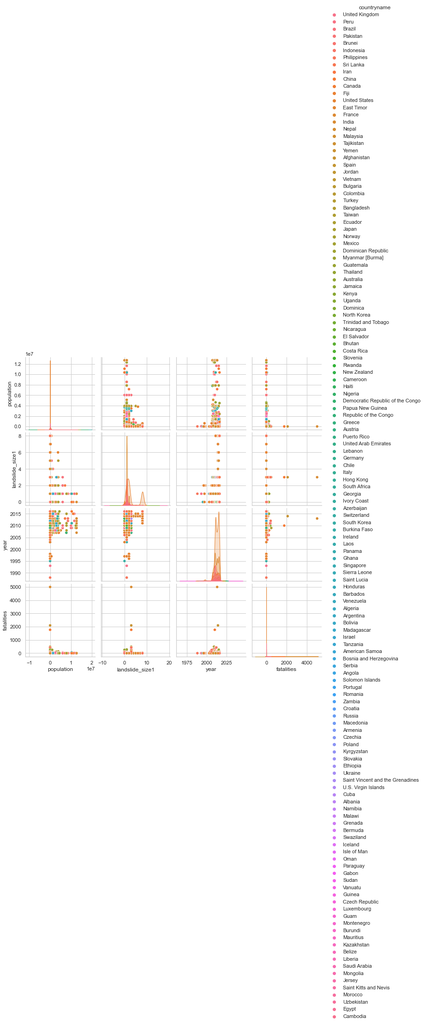

```python
# Seaborn visualization library
import seaborn as sns
# Create the default pairplot
sns.pairplot(dt2, hue='countryname')
```

FIGURE 8: THIS IS A PLOT BETWEEN TRIGGER AND HAZARD TYPE. I PLOTTED THIS TO GET A RELATIONSHIP THAT HOW DIFFERENT TRIGGER PARAMETERS CHANGES THE HAZARD TYPE.

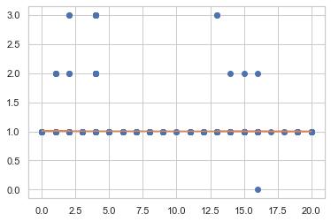

```python
x = dt1['trigger_label']
y = dt1['hazard_type_label']
import matplotlib.pyplot as plt

#create basic scatterplot
plt.plot(x, y, 'o')

#obtain m (slope) and b(intercept) of linear regression line
m, b = np.polyfit(x, y, 1)

#add linear regression line to scatterplot
plt.plot(x, m*x+b)
```

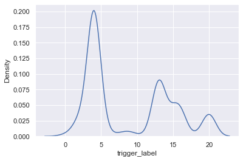

```python
# libraries & dataset
import seaborn as sns
import matplotlib.pyplot as plt
# set a grey background (use sns.set_theme() if seaborn version 0.11.0 or above)
sns.set(style="darkgrid")

# Make default density plot
sns.kdeplot(dt1['trigger_label'])
plt.show()
```

FIGURE 10: IT IS VERY INTERESTING PLOT. IT IS BETWEEN INJURIES AND FATALITIES OCCURED OVER THE YEARS. WHILE RED DOTS IN DIFFERENT SIZED ARE PLOTTED BY TAKING "POPULATION" PARAMETER AS A SIZE. SO WE CAN FROM THIS PLOT EASILY INTERPRET THAT MAJORITY OF THE POPULATION DID NOT GET ANY SEVERE INJURIES AND FATALITIES. BUT, A SMALLER PORTION OF POPULATION ALSO GOT SOME DAMAGE (RED DOTS IN MIDDLE)

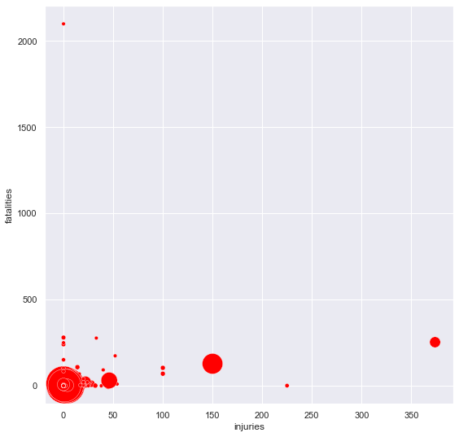

```python
# libraries
import matplotlib.pyplot as plt
import seaborn as sns
from gapminder import gapminder # import data set

# Control figure size for this notebook:
plt.rcParams['figure.figsize'] = [9, 9]



# use the scatterplot function to build the bubble map
sns.scatterplot(data=dt1, x="injuries", y="fatalities", size="population", legend=False, sizes=(20, 2000), color='red')

# show the graph
plt.show()
```

FIGURE 11: THIS IS A PLOT I PLOTTED INITIALLY TO HAVE AN IDEA THAT ARE DISTANCE AND HAZARD TYPE SHARE SOME RELATIONSHIP OR NOT. SO I FOUND THAT ALTHOUGH THEY DID NOT HAVE STRONG RELATIONSHIP, BUT WE CAN SEE THAT HAZARD TYPE 1 IS OCCURING ACROSS ALL THE DISTANCES.

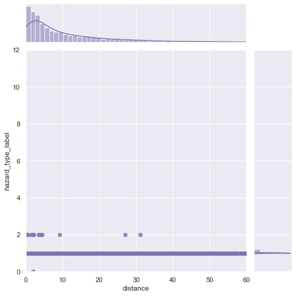

```python
import seaborn as sns
sns.set_theme(style="darkgrid")


g = sns.jointplot(x="distance", y="hazard_type_label", data=dt1,
                  kind="reg", truncate=False,
                  xlim=(0, 60), ylim=(0, 12),
                  color="m", height=7)
```

```python
values = ['United States']
dt3 = dt1[dt1. countryname.isin(values) == True]
dt3.head()
```

|  | id | date | time | hazard_type | landslide_type | trigger | fatalities | injuries | location_accuracy | landslide_size | ... | distance | population | continentcode | latitude | longitude | year | country_name | landslide_size1 | trigger_label | hazard_type_label |
| --- | --- | --- | --- | --- | --- | --- | --- | --- | --- | --- | --- | --- | --- | --- | --- | --- | --- | --- | --- | --- | --- |
| 23 | 24 | 02/11/2007 | NaN | landslide | Landslide | Rain | NaN | NaN | Known_within_5_km | Small | ... | 9.96508 | 2933.0 | NaN | 38.4909 | -122.3494 | 2007.0 | 134 | 2 | 13 | 1 |
| 26 | 27 | 02/15/2007 | NaN | landslide | Landslide | Rain | NaN | NaN | Exact_Location | Medium | ... | 0.67264 | 1465.0 | NaN | 45.6993 | -121.8950 | 2007.0 | 134 | 1 | 13 | 1 |
| 29 | 30 | 02/27/2007 | NaN | landslide | Complex | Rain | NaN | NaN | Known_within_5_km | Medium | ... | 4.28838 | 805235.0 | NaN | 37.7923 | -122.4629 | 2007.0 | 134 | 1 | 13 | 1 |
| 33 | 34 | 03/02/2007 | night | landslide | Landslide | Rain | NaN | NaN | Known_within_1km | Small | ... | 3.40765 | 16000.0 | NaN | 38.6009 | -77.2682 | 2007.0 | 134 | 2 | 13 | 1 |
| 41 | 42 | 03/22/2007 | NaN | landslide | Landslide | Rain | NaN | NaN | Known_within_5_km | Small | ... | 3.33522 | 17288.0 | NaN | 40.5175 | -81.4305 | 2007.0 | 134 | 2 | 13 | 1 |

5 rows × 22 columns

FIGURE 12: THIS IS THE LAST PLOT I PLOTTED TO GET AN IDEA ABOUT THIS DATASET ESPECIALLY ACROSS THE UNITED STATES OF AMERICA. IT IS DESCRIBING THE RELATIONSHIP BETWEEN YEAR AND POPULATION OF UNITED STATES OF AMERICA.

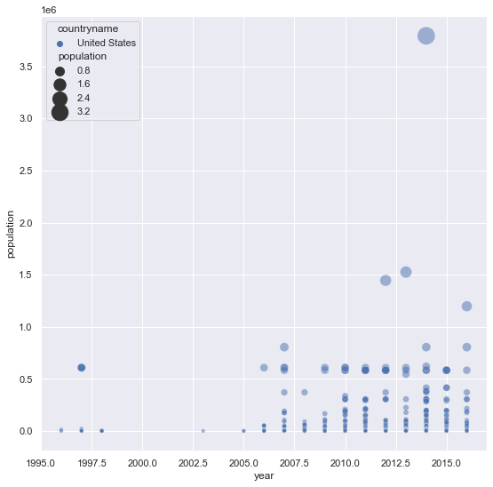

```python
# use the scatterplot function
sns.scatterplot(data=dt3, x="year", y="population", size="population", hue="countryname", alpha=0.5, sizes=(20, 400))

# show the graph
plt.show()
```

# Q2 PART (A) APPLY RANDOM FOREST AND GRADIENT BOOST ON YOU CLIMATE DATASET FROM PREVIOUS ASSIGNMENT

```python
import time
start = time.time()

import pandas as pd
import numpy as np
pd.set_option('display.max_columns', 1500)

import warnings
warnings.filterwarnings('ignore')

# -- Extend cell width

from IPython.core.display import display, HTML
display(HTML("<style>.container { width:80% !important; }</style>"))
```

```python
import pandas as pd
import numpy as np
```

```python
data = pd.read_csv('Book6.csv')
```

```python
data
```

|  | Date | N2O Monthly averaged | Temperature anomaly | CH4 Monthly averaged | CO2 Monthly averaged |
| --- | --- | --- | --- | --- | --- |
| 0 | 1850-01-15 | NaN | NaN | NaN | NaN |
| 1 | 1850-02-15 | NaN | NaN | NaN | NaN |
| 2 | 1850-03-15 | NaN | NaN | NaN | NaN |
| 3 | 1850-04-15 | NaN | NaN | NaN | NaN |
| 4 | 1850-05-15 | NaN | NaN | NaN | NaN |
| ... | ... | ... | ... | ... | ... |
| 2882 | 7/16/22 | NaN | NaN | NaN | NaN |
| 2883 | 8/15/22 | NaN | 0.94 | NaN | NaN |
| 2884 | 8/16/22 | NaN | NaN | NaN | NaN |
| 2885 | 9/15/22 | NaN | 0.88 | NaN | NaN |
| 2886 | 9/16/22 | NaN | NaN | NaN | NaN |

2887 rows × 5 columns

```python
df = data.copy()
```

```python
conda install -c conda-forge missingno
```

```
Solving environment: done

# All requested packages already installed.

Retrieving notices: ...working... done
```

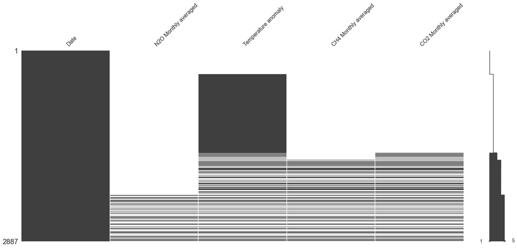

```python
import missingno as msno
msno.matrix(df)
```

```python
df2=df.dropna()
df2=df.dropna(axis=0)
df2.head()
```

|  | Date | N2O Monthly averaged | Temperature anomaly | CH4 Monthly averaged | CO2 Monthly averaged |
| --- | --- | --- | --- | --- | --- |
| 2185 | 1/15/01 | 316.30 | 0.45 | 1772.86 | 370.69 |
| 2189 | 2/15/01 | 316.31 | 0.44 | 1772.48 | 371.18 |
| 2191 | 3/15/01 | 316.21 | 0.55 | 1773.64 | 371.59 |
| 2194 | 4/15/01 | 316.12 | 0.50 | 1773.84 | 371.90 |
| 2197 | 5/15/01 | 316.11 | 0.57 | 1770.71 | 371.80 |

```python
df2.count()
```

```
Date                    258
N2O Monthly averaged    258
Temperature anomaly     258
CH4 Monthly averaged    258
CO2 Monthly averaged    258
dtype: int64
```

```python
df2['Date'] = pd.to_datetime(data['Date'])
```

```python
df2
```

|  | Date | N2O Monthly averaged | Temperature anomaly | CH4 Monthly averaged | CO2 Monthly averaged |
| --- | --- | --- | --- | --- | --- |
| 2185 | 2001-01-15 | 316.30 | 0.45 | 1772.86 | 370.69 |
| 2189 | 2001-02-15 | 316.31 | 0.44 | 1772.48 | 371.18 |
| 2191 | 2001-03-15 | 316.21 | 0.55 | 1773.64 | 371.59 |
| 2194 | 2001-04-15 | 316.12 | 0.50 | 1773.84 | 371.90 |
| 2197 | 2001-05-15 | 316.11 | 0.57 | 1770.71 | 371.80 |
| ... | ... | ... | ... | ... | ... |
| 2871 | 2022-02-15 | 335.35 | 0.89 | 1907.94 | 417.64 |
| 2873 | 2022-03-15 | 335.40 | 1.05 | 1909.23 | 418.05 |
| 2875 | 2022-04-15 | 335.46 | 0.83 | 1909.98 | 418.42 |
| 2877 | 2022-05-15 | 335.48 | 0.83 | 1908.67 | 418.48 |
| 2879 | 2022-06-15 | 335.48 | 0.92 | 1906.11 | 417.45 |

258 rows × 5 columns

```python
df3 = df2.copy()
```

```python
from sklearn import preprocessing
```

```python
label_encoder = preprocessing.LabelEncoder()

df3['Temperature anomaly']= label_encoder.fit_transform(df3['Temperature anomaly'])

df3['Temperature anomaly'].unique()
```

```
array([ 5,  4, 14, 10, 16, 11, 18,  9, 31, 15, 36, 38, 47, 17, 23, 12, 20,
       22, 13, 34,  8, 21,  2,  0, 19, 33, 26, 30, 32, 27,  7, 24, 28, 57,
       29, 35,  1,  3,  6, 42, 51, 43, 40, 25, 37, 45, 41, 46, 39, 44, 49,
       54, 60, 58, 63, 64, 67, 66, 61, 56, 50, 62, 53, 52, 48, 55, 59, 65])
```

```python
df3
```

|  | Date | N2O Monthly averaged | Temperature anomaly | CH4 Monthly averaged | CO2 Monthly averaged |
| --- | --- | --- | --- | --- | --- |
| 2185 | 2001-01-15 | 316.30 | 5 | 1772.86 | 370.69 |
| 2189 | 2001-02-15 | 316.31 | 4 | 1772.48 | 371.18 |
| 2191 | 2001-03-15 | 316.21 | 14 | 1773.64 | 371.59 |
| 2194 | 2001-04-15 | 316.12 | 10 | 1773.84 | 371.90 |
| 2197 | 2001-05-15 | 316.11 | 16 | 1770.71 | 371.80 |
| ... | ... | ... | ... | ... | ... |
| 2871 | 2022-02-15 | 335.35 | 48 | 1907.94 | 417.64 |
| 2873 | 2022-03-15 | 335.40 | 58 | 1909.23 | 418.05 |
| 2875 | 2022-04-15 | 335.46 | 42 | 1909.98 | 418.42 |
| 2877 | 2022-05-15 | 335.48 | 42 | 1908.67 | 418.48 |
| 2879 | 2022-06-15 | 335.48 | 51 | 1906.11 | 417.45 |

258 rows × 5 columns

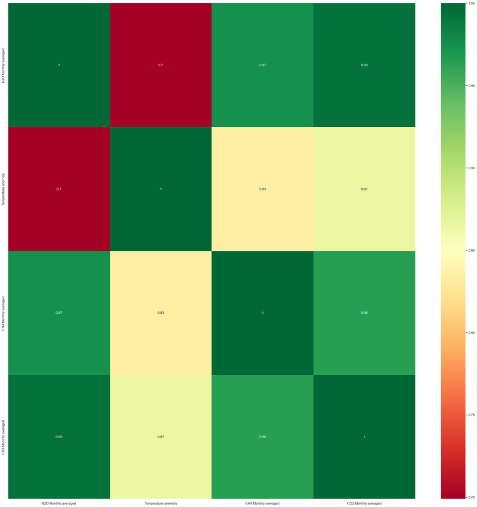

```python
import seaborn as sns
import matplotlib.pyplot as plt

# -- heat map to see corrolation between features
corrmat = df3.corr()
top_corr_features = corrmat.index
plt.figure(figsize=(30,30))

# -- plot heat map
sns.heatmap(data[top_corr_features].corr(),annot=True,cmap="RdYlGn",)
```

```python
import pandas as pd
import numpy as np
import matplotlib.pyplot as plt
import warnings
from pandas.plotting import scatter_matrix
warnings.filterwarnings("ignore")
```

# APPLYING RANDOM FOREST

[output not shown]

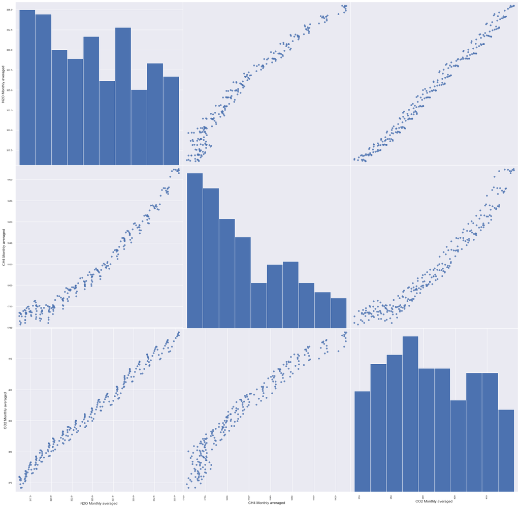

```python
%matplotlib inline
from pandas.plotting import scatter_matrix
features = ['CO2 Monthly averaged', 'CH4 Monthly averaged', 'N2O Monthly averaged']
X = df3.loc[:, features]
y = df3.loc[:, ['Temperature anomaly']]
attributes = df3.drop(columns='Temperature anomaly')
scatter_matrix(attributes, figsize=(30,30), alpha=0.8, marker='O')
```

```python
from sklearn.ensemble import RandomForestClassifier
from sklearn.model_selection import train_test_split
```

```python
X_train, X_test, y_train, y_test = train_test_split(
    X, y, random_state=0)
forest = RandomForestClassifier(n_estimators=100, random_state=0)
forest.fit(X_train, y_train)

print("Accuracy on training set: {:.3f}".format(forest.score(X_train, y_train)))
print("Accuracy on test set: {:.3f}".format(forest.score(X_test, y_test)))
```

```
Accuracy on training set: 1.000
Accuracy on test set: 0.046
```

```python
forest.feature_importances_
```

```
array([0.32967106, 0.33824215, 0.33208679])
```

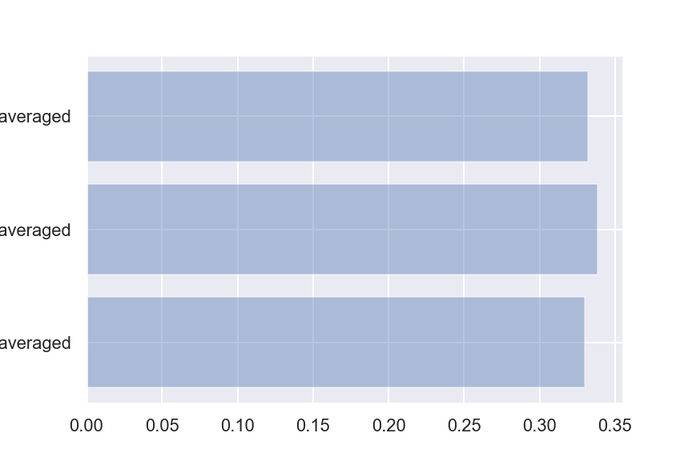

[output not shown]

```python
%matplotlib notebook

y_list = forest.feature_importances_
y_pos = np.arange(len(y_list))
features =['CO2 Monthly averaged', 'CH4 Monthly averaged', 'N2O Monthly averaged']
plt.barh(y_pos, y_list, align='center', alpha=0.4)
plt.yticks(y_pos, features)
```

# APPLYING GRADIENT BOOST

```python
from sklearn.ensemble import GradientBoostingClassifier

X_train, X_test, y_train, y_test = train_test_split(X, y, random_state=0)

gbrt = GradientBoostingClassifier(random_state=0)
gbrt.fit(X_train, y_train)

print("Accuracy on training set: {:.3f}".format(gbrt.score(X_train, y_train)))
print("Accuracy on test set: {:.3f}".format(gbrt.score(X_test, y_test)))
```

```
Accuracy on training set: 1.000
Accuracy on test set: 0.077
```

```python
gbrt = GradientBoostingClassifier(random_state=0, max_depth=1)
gbrt.fit(X_train, y_train)

print("Accuracy on training set: {:.3f}".format(gbrt.score(X_train, y_train)))
print("Accuracy on test set: {:.3f}".format(gbrt.score(X_test, y_test)))
```

```
Accuracy on training set: 0.865
Accuracy on test set: 0.062
```

```python
gbrt = GradientBoostingClassifier(random_state=0, learning_rate=0.01)
gbrt.fit(X_train, y_train)

print("Accuracy on training set: {:.3f}".format(gbrt.score(X_train, y_train)))
print("Accuracy on test set: {:.3f}".format(gbrt.score(X_test, y_test)))
```

```
Accuracy on training set: 0.984
Accuracy on test set: 0.062
```

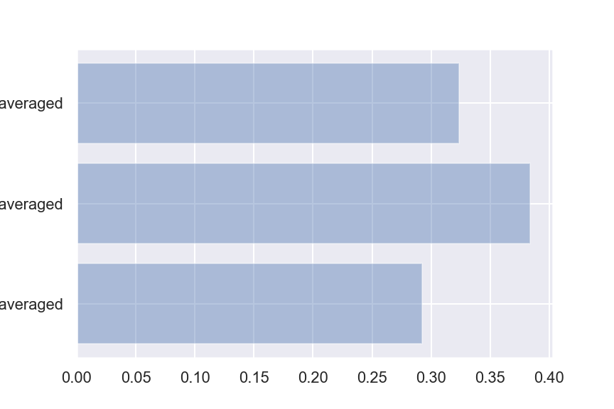

[output not shown]

```python
%matplotlib notebook

y_list = gbrt.feature_importances_
y_pos = np.arange(len(y_list))
features = ['CO2 Monthly averaged', 'CH4 Monthly averaged', 'N2O Monthly averaged']
plt.barh(y_pos, y_list, align='center', alpha=0.4)
plt.yticks(y_pos, features)
```

# Q2 PART (B) ENSEMBLE THE 4 MODELS FROM ASSIGNMENT 5

NOTE: I HAVE 5 MODELS FROM ASSIGNMENT 5. I WILL IMPORT THOSE 5 MODELS HERE, AND WILL ENSEMBLE 4 OF THEM. ALTHOUGH THINGS ARE MAKING SENSE, BUT HAVE LOW SCORE. IT IS BECAUSE WE DID A LOT OF CLEANING IN THE ASSIGNMENT 5.

# KNN REGRESSOR

```python
from sklearn.preprocessing import MinMaxScaler

drop_col_MinMax=[]
num_scalers = {}

for col in X:
    if pd.api.types.is_numeric_dtype(X[col].dtype): # just making sure all numberic are choosen, this line can be deleted
        print("MinMax scale of ", col)
        scaler = MinMaxScaler()
        scaler.fit(X[[col]])
        X[col+"_normalized"] = scaler.transform(X[[col]])
        drop_col_MinMax.append(col)



# -- view final file
X = X.drop(columns=drop_col_MinMax)
X.head(3)
```

```
MinMax scale of  CO2 Monthly averaged
MinMax scale of  CH4 Monthly averaged
MinMax scale of  N2O Monthly averaged
```

|  | CO2 Monthly averaged_normalized | CH4 Monthly averaged_normalized | N2O Monthly averaged_normalized |
| --- | --- | --- | --- |
| 2185 | 0.047249 | 0.068858 | 0.009809 |
| 2189 | 0.057018 | 0.066277 | 0.010325 |
| 2191 | 0.065191 | 0.074155 | 0.005163 |

```python
from sklearn.neighbors import KNeighborsRegressor

from sklearn.model_selection import train_test_split
X_train, X_test, y_train, y_test = train_test_split(X, y, random_state = 0, test_size = 0.25)
```

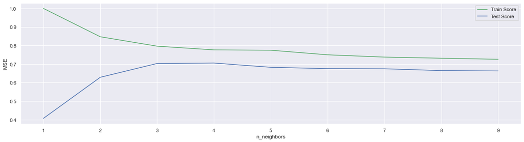

```python
%matplotlib inline
train_score_array = []
test_score_array = []

for k in range(1,10):
    knn_reg = KNeighborsRegressor(k)
    knn_reg.fit(X_train, y_train)
    train_score_array.append(knn_reg.score(X_train, y_train))
    test_score_array.append(knn_reg.score(X_test, y_test))

x_axis = range(1,10)
plt.subplots(figsize = (20,5))
plt.plot(x_axis, train_score_array, c = 'g', label = 'Train Score')
plt.plot(x_axis, test_score_array, c = 'b', label = 'Test Score')
plt.legend()
plt.xlabel('n_neighbors')
plt.ylabel('MSE')
```

```python
from sklearn.metrics import mean_squared_error

# -- fit algoritem to train data
knn_reg3 = KNeighborsRegressor(3)
knn_reg3.fit(X_train, y_train)

# -- predict target value for test dataset
y_predict_knn = knn_reg.predict(X_test)

# -- comapre target value of the model and abservation for both train and test dataset
print (knn_reg.score(X_train,y_train))
print (knn_reg.score(X_test,y_test))
```

```
0.7256391758791789
0.6627973687874403
```